# Midterm Prep

Thursday: How to turn exploration into a clear analysis

Author

Casey Schine

# 1. Recap

### Workflow:

Question → Plot → Pattern → Interpretation

```r
library(tidyverse)
library(scales)
library(ggthemes)

#code to read in data
getwd()
```

```
[1] "/Users/caseysmith/Dropbox/!Middlebury/Teaching/STAT 118/S2026/S2026_R_Proj/In_class_notes"
```

```r
# EJI
library(sf)
eji_data <- st_read("~/Dropbox/!Middlebury/Teaching/STAT 118/S2026/S2026_R_Proj/midterm/eji_sf.gpkg")
# YRBS
yrbs_data <- read_csv("~/Dropbox/!Middlebury/Teaching/STAT 118/S2026/S2026_R_Proj/midterm/yrbss_2024.csv")
```

Plot we made using the EJI dataset looking at the relationship between smoke exposure and cancer levels.

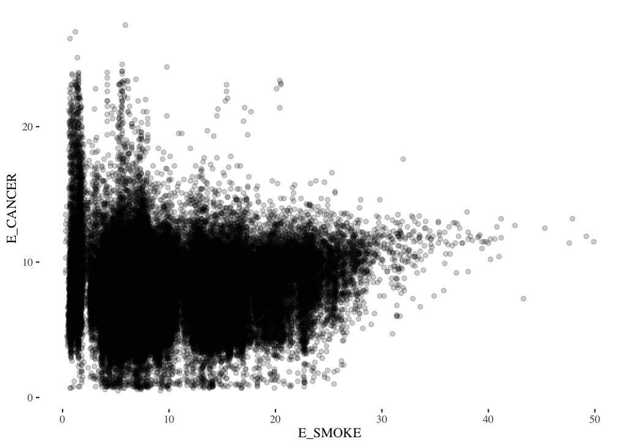

```r
#variables to explore smoke v. cancer
#E_SMOKE
#E_CANCER
eji_data |>
  #filter(STATE_NAME=="California") |>
  ggplot() +
  geom_point(aes(x=E_SMOKE, y=E_CANCER), alpha=0.2) +
  #scale_x_log10() +
  theme_tufte()
```

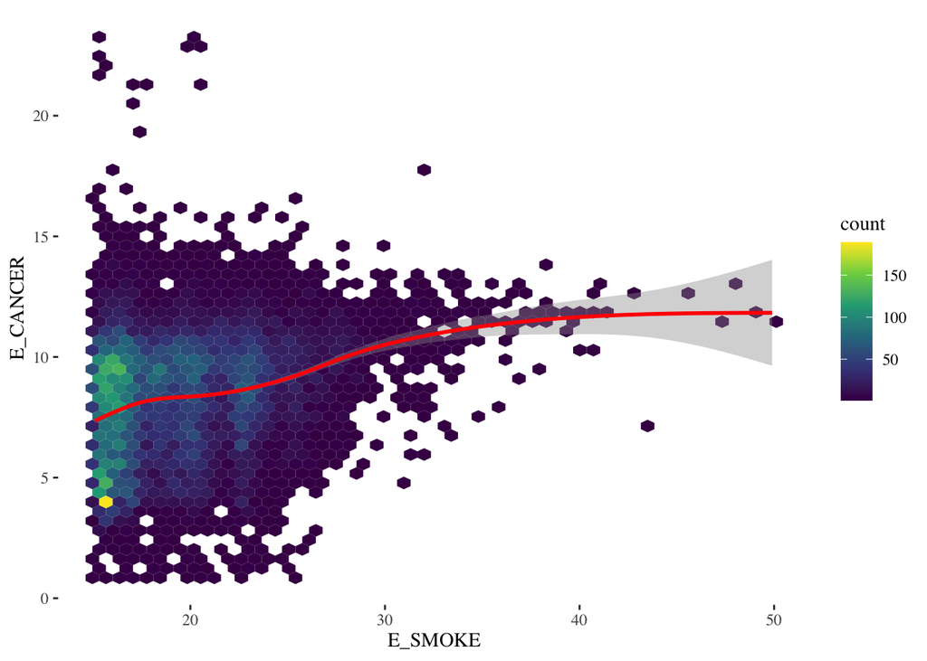

```r
eji_data |>
  filter(E_SMOKE>15) |>
  ggplot(aes(x=E_SMOKE, y=E_CANCER)) +
  geom_hex(bins=50) +
  geom_smooth(color="red") +
  scale_fill_viridis_c() +
  #scale_x_log10() +
  theme_tufte()
```

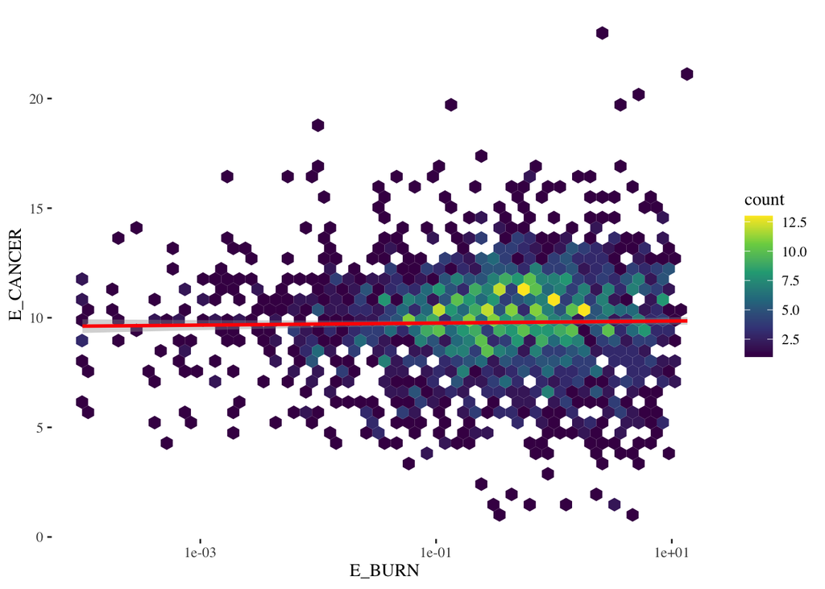

```r
eji_data |>
  #filter(E_SMOKE>15) |>
  ggplot(aes(x=E_BURN, y=E_CANCER)) +
  geom_hex(bins=50) +
  geom_smooth(color="red") +
  scale_fill_viridis_c() +
  scale_x_log10() +
  theme_tufte()
```

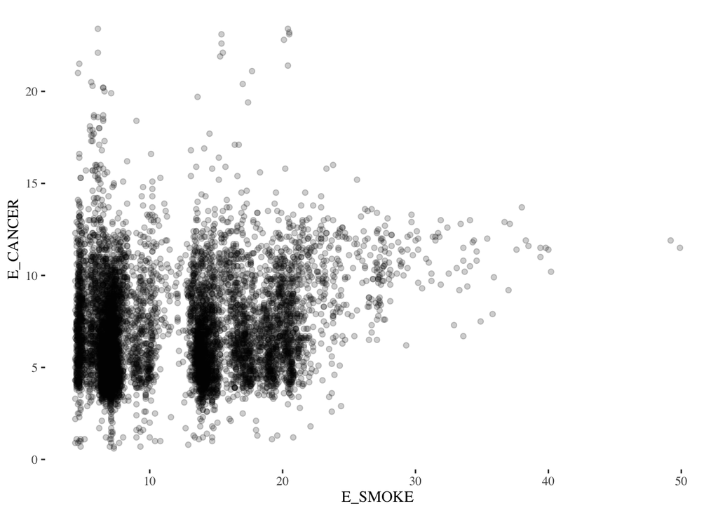

```r
eji_data |>
  filter(STATE_NAME=="California") |>
  ggplot() +
  geom_point(aes(x=E_SMOKE, y=E_CANCER), alpha=0.2) +
  theme_tufte()
```

### In your report:

Introduction → dataset + question

Results → plots + patterns

Discussion → interpretation

# 2. Group check-in: What questions are you exploring?

Each person briefly share, what question you are currently exploring and how you are approaching it. Help your group mates clarify and refine their questions.

# 3. Question → Plot

Plot choice is part of the reasoning process, not simply decoration.

Give me some example questions.

What kind of plot would help answer this?

# 4. Turning messy plots into clear plots

Let’s take a rough exploratory plot and improve it.

Possible improvements:

- reorder categories
- simplify colors
- improve axis labels
- add clear titles
- remove unnecessary clutter

Explain:

Your first plots help you explore. The plots in your report should help the reader understand the pattern.

# 5. Results versus Discussion

```r
#make example plot
```

Write down answers and separate into what belongs in the results and what belongs in the discussion.

### Results = describe pattern

### Discussion = explain pattern

# 6. Studio work

Work on your project with your group. Ask questions and help each other debug code.

# 7. End-of-class checkpoint

Finish these statements:

- My question is…
- My two key plots will show…
- The main pattern I see is…